# Introduction to rbin

Aravind Hebbali

2026-11-18

## Introduction

Binning is the process of transforming numerical or continuous data into categorical data. It is a common data pre-processing step of the model building process.

rbin has the following features:

- manual binning using shiny app
- equal length binning method
- winsorized binning method
- quantile binning method
- tie-aware equal frequency binning method
- combine levels of categorical data
- create dummy variables based on binning method
- calculates weight of evidence (WOE), entropy and information value (IV)
- provides summary information about binning pre-processing

## Manual Binning

For manual binning, you need to specify the cut points for the bins. `rbin` follows the left closed and right open interval (`[0,1) = {x | 0 ≤ x < 1}`) for creating bins. The number of cut points you specify is one less than the number of bins you want to create i.e. if you want to create 10 bins, you need to specify only 9 cut points as shown in the below example. The accompanying RStudio addin, `rbinAddin()` can be used to iteratively bin the data and to enforce monotonic increasing/decreasing trend.

After finalizing the bins, you can use `rbin_create()` to create the dummy variables.

### Bins

```r
bins <- rbin_manual(mbank, y, age, c(29, 31, 34, 36, 39, 42, 46, 51, 56))
bins
```

```
#> Binning Summary
#> ---------------------------
#> Method               Manual
#> Response             y
#> Predictor            age
#> Bins                 10
#> Count                4521
#> Goods                517
#> Bads                 4004
#> Entropy              0.5
#> Information Value    0.12
#>
#>
#>    cut_point bin_count good bad          woe           iv   entropy
#> 1       < 29       410   71 339 -0.483686036 2.547353e-02 0.6649069
#> 2       < 31       313   41 272 -0.154776266 1.760055e-03 0.5601482
#> 3       < 34       567   55 512  0.183985174 3.953685e-03 0.4594187
#> 4       < 36       396   45 351  0.007117468 4.425063e-06 0.5107878
#> 5       < 39       519   47 472  0.259825118 7.008270e-03 0.4383322
#> 6       < 42       431   33 398  0.442938178 1.575567e-02 0.3899626
#> 7       < 46       449   47 402  0.099298221 9.423907e-04 0.4836486
#> 8       < 51       521   40 481  0.439981550 1.881380e-02 0.3907140
#> 9       < 56       445   49 396  0.042587647 1.756117e-04 0.5002548
#> 10     >= 56       470   89 381 -0.592843261 4.564428e-02 0.7001343
```

### Plot

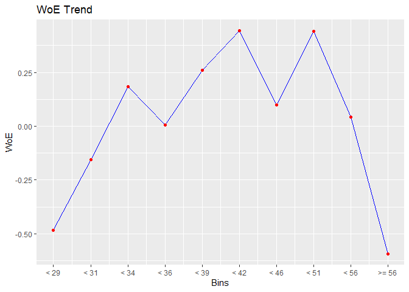

```r
# plot
plot(bins)
```

### Dummy Variables

```r
bins <- rbin_manual(mbank, y, age, c(29, 31, 34, 36, 39, 42, 46, 51, 56))
rbin_create(mbank, age, bins)
```

```
#>      age           job  marital education default balance housing loan
#> 1     34    technician  married  tertiary      no     297     yes   no
#> 2     49      services  married secondary      no     180     yes  yes
#> 3     38        admin.   single secondary      no     262      no   no
#> 4     47      services  married secondary      no     367     yes   no
#> 5     51 self-employed   single secondary      no    1640     yes   no
#> 6     40    unemployed  married secondary      no    3382     yes   no
#> 7     58       retired  married secondary      no    1227      no   no
#> 8     32    unemployed  married   primary      no     309     yes   no
#> 9     46   blue-collar  married secondary      no     922     yes   no
#> 10    32      services  married  tertiary      no       0      no   no
#> 11    32      services  married secondary      no     414     yes   no
#> 12    50   blue-collar  married   primary      no       0      no   no
#> 13    41    management  married  tertiary      no    2226      no   no
#> 14    38      services divorced   primary      no       0     yes   no
```

[output cut: 14802 more lines]

## Factor Binning

You can collapse or combine levels of a factor/categorical variable using `rbin_factor_combine()` and then use `rbin_factor()` to look at weight of evidence, entropy and information value. After finalizing the bins, you can use `rbin_factor_create()` to create the dummy variables. You can use the RStudio addin, `rbinFactorAddin()` to interactively combine the levels and create dummy variables after finalizing the bins.

### Combine Levels

```r
upper <- c("secondary", "tertiary")
out <- rbin_factor_combine(mbank, education, upper, "upper")
table(out$education)
```

```
#>
#>   upper unknown primary
#>    3651     179     691
```

```r
out <- rbin_factor_combine(mbank, education, c("secondary", "tertiary"), "upper")
table(out$education)
```

```
#>
#>   upper unknown primary
#>    3651     179     691
```

### Bins

```r
bins <- rbin_factor(mbank, y, education)
bins
```

```
#> Binning Summary
#> ---------------------------
#> Method               Custom
#> Response             y
#> Predictor            education
#> Levels               4
#> Count                4521
#> Goods                517
#> Bads                 4004
#> Entropy              0.51
#> Information Value    0.05
#>
#>
#>       level bin_count good  bad        woe          iv   entropy
#> 1  tertiary      1299  195 1104 -0.3133106 0.031785905 0.6101292
#> 2 secondary      2352  231 2121  0.1702190 0.014113157 0.4633093
#> 3   primary       691   66  625  0.2010906 0.005717878 0.4546110
#> 4   unknown       179   25  154 -0.2289295 0.002265111 0.5833603
```

#### Plot

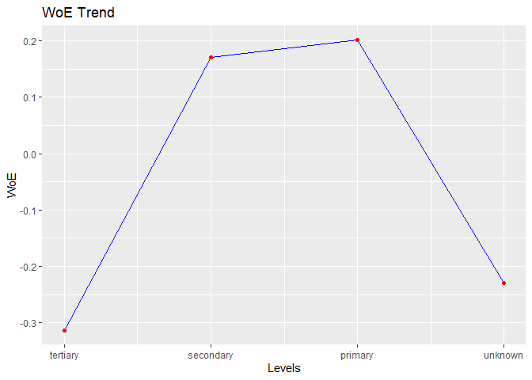

```r
# plot
plot(bins)
```

### Create Bins

```r
upper <- c("secondary", "tertiary")
out <- rbin_factor_combine(mbank, education, upper, "upper")
rbin_factor_create(out, education)
```

```
#>      age           job  marital education default balance housing loan
#> 1     34    technician  married     upper      no     297     yes   no
#> 2     49      services  married     upper      no     180     yes  yes
#> 3     38        admin.   single     upper      no     262      no   no
#> 4     47      services  married     upper      no     367     yes   no
#> 5     51 self-employed   single     upper      no    1640     yes   no
#> 6     40    unemployed  married     upper      no    3382     yes   no
#> 7     58       retired  married     upper      no    1227      no   no
#> 8     32    unemployed  married   primary      no     309     yes   no
#> 9     46   blue-collar  married     upper      no     922     yes   no
#> 10    32      services  married     upper      no       0      no   no
#> 11    32      services  married     upper      no     414     yes   no
#> 12    50   blue-collar  married   primary      no       0      no   no
#> 13    41    management  married     upper      no    2226      no   no
#> 14    38      services divorced   primary      no       0     yes   no
```

[output cut: 13551 more lines]

## Quantile Binning

Quantile binning aims to bin the data into roughly equal groups using quantiles.

```r
bins <- rbin_quantiles(mbank, y, age, 10)
bins
```

```
#> Binning Summary
#> -----------------------------
#> Method               Quantile
#> Response             y
#> Predictor            age
#> Bins                 10
#> Count                4521
#> Goods                517
#> Bads                 4004
#> Entropy              0.5
#> Information Value    0.12
#>
#>
#>    cut_point bin_count good bad          woe           iv   entropy
#> 1       < 29       410   71 339 -0.483686036 2.547353e-02 0.6649069
#> 2       < 31       313   41 272 -0.154776266 1.760055e-03 0.5601482
#> 3       < 34       567   55 512  0.183985174 3.953685e-03 0.4594187
#> 4       < 36       396   45 351  0.007117468 4.425063e-06 0.5107878
#> 5       < 39       519   47 472  0.259825118 7.008270e-03 0.4383322
#> 6       < 42       431   33 398  0.442938178 1.575567e-02 0.3899626
#> 7       < 46       449   47 402  0.099298221 9.423907e-04 0.4836486
#> 8       < 51       521   40 481  0.439981550 1.881380e-02 0.3907140
#> 9       < 56       445   49 396  0.042587647 1.756117e-04 0.5002548
#> 10     >= 56       470   89 381 -0.592843261 4.564428e-02 0.7001343
```

#### Plot

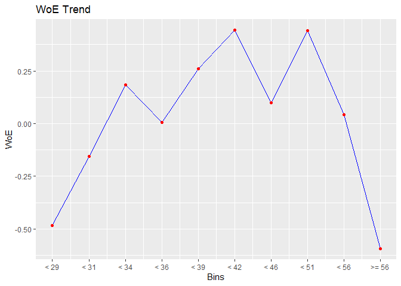

```r
# plot
plot(bins)
```

## Equal Frequency Binning

Equal-frequency binning creates approximately equal groups without splitting tied values. For each target `k * n / bins` among non-missing predictors, the smallest value whose cumulative count reaches that target, including all its ties, stays in the lower group. The next distinct observed value starts the next group. Repeated cuts and cuts beyond the maximum are omitted, with a message giving the requested and actual number of non-missing bins.

The stored intervals are left closed and right open, with unbounded outer intervals. Gaps belong to the preceding group. Missing predictors retain a separate final summary group and produce missing dummy indicators.

```r
bins <- rbin_equal_freq(mbank, y, age, 10)
bins
```

```
#> Binning Summary
#> ------------------------------------
#> Method               Equal Frequency
#> Response             y
#> Predictor            age
#> Bins                 10
#> Count                4521
#> Goods                517
#> Bads                 4004
#> Entropy              0.5
#> Information Value    0.11
#>
#>
#>    lower_cut upper_cut bin_count good bad  good_rate         woe           iv
#> 1       -Inf        30       521   85 436 0.16314779 -0.41201528 2.287466e-02
#> 2         30        32       386   45 341 0.11658031 -0.02178628 4.086635e-05
#> 3         32        35       582   57 525 0.09793814  0.17334073 3.617176e-03
#> 4         35        37       374   38 336 0.10160428  0.13251873 1.380198e-03
#> 5         37        40       497   44 453 0.08853119  0.28469623 7.980172e-03
#> 6         40        43       396   37 359 0.09343434  0.22539821 4.078267e-03
#> 7         43        47       461   43 418 0.09327549  0.22727505 4.823562e-03
#> 8         47        52       474   41 433 0.08649789  0.31015940 8.944433e-03
#> 9         52        57       441   47 394 0.10657596  0.07919704 5.933844e-04
#> 10        57       Inf       389   80 309 0.20565553 -0.69569162 5.396205e-02
#>      entropy
#> 1  0.6417872
#> 2  0.5194505
#> 3  0.4624254
#> 4  0.4740605
#> 5  0.4315480
#> 6  0.4478305
#> 7  0.4473095
#> 8  0.4246709
#> 9  0.4895008
#> 10 0.7330960
```

```r
colSums(rbin_create(mbank, age, bins)[-seq_along(mbank)])
```

```
#>  age_<_30  age_<_32  age_<_35  age_<_37  age_<_40  age_<_43  age_<_47  age_<_52
#>       521       386       582       374       497       396       461       474
#>  age_<_57 age_>=_57
#>       441       389
```

#### Plot

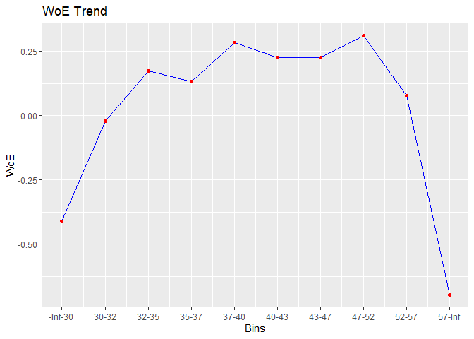

```r
plot(bins)
```

## Equal Length Binning

Equal length binning creates bins of equal widths. It is different from equal frequency binning which creates bins of approximately equal size while keeping ties together.

```r
bins <- rbin_equal_length(mbank, y, age, 10)
bins
```

```
#> Binning Summary
#> ---------------------------------
#> Method               Equal Length
#> Response             y
#> Predictor            age
#> Bins                 10
#> Count                4521
#> Goods                517
#> Bads                 4004
#> Entropy              0.5
#> Information Value    0.17
#>
#>
#>    cut_point bin_count good  bad         woe           iv   entropy
#> 1     < 24.6        85   24   61 -1.11418623 0.0347480126 0.8586371
#> 2     < 31.2       822  106  716 -0.13676519 0.0035843196 0.5545619
#> 3     < 37.8      1133  115 1018  0.13365680 0.0042514380 0.4737339
#> 4     < 44.4       943   82  861  0.30436899 0.0171748162 0.4262287
#> 5       < 51       623   52  571  0.34913923 0.0146733167 0.4142794
#> 6     < 57.6       612   66  546  0.06595797 0.0005741022 0.4933757
#> 7     < 64.2       229   43  186 -0.58245971 0.0213871054 0.6967893
#> 8     < 70.8        34   12   22 -1.44087046 0.0255269312 0.9366674
#> 9     < 77.4        25   13   12 -2.12704897 0.0471100183 0.9988455
#> 10   >= 77.4        15    4   11 -1.03540535 0.0051663529 0.8366407
```

#### Plot

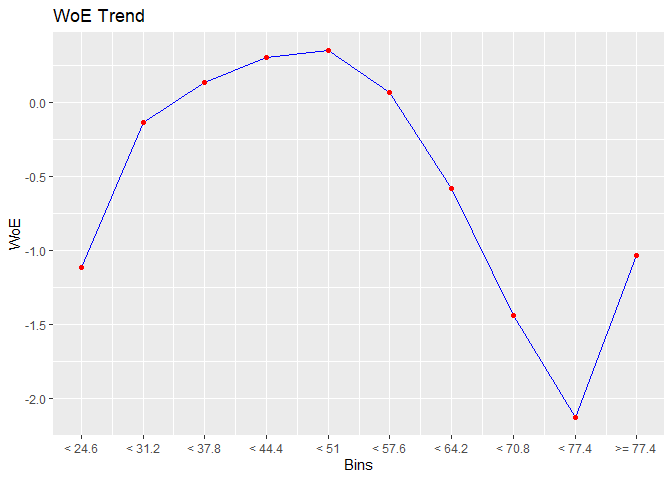

```r
# plot
plot(bins)
```

## Winsorized Binning

Winsorized binning is similar to equal length binning except that both tails are cut off to obtain a smooth binning result. This technique is often used to remove outliers during the data pre-processing stage. For Winsorized binning, the Winsorized statistics are computed first. After the minimum and maximum have been found, the split points are calculated the same way as in equal length binning.

```r
bins <- rbin_winsorize(mbank, y, age, 10, winsor_rate = 0.05)
bins
```

```
#> Binning Summary
#> ------------------------------
#> Method               Winsorize
#> Response             y
#> Predictor            age
#> Bins                 10
#> Count                4521
#> Goods                517
#> Bads                 4004
#> Entropy              0.51
#> Information Value    0.1
#>
#>
#>    cut_point bin_count good bad        woe           iv   entropy
#> 1     < 30.2       723  112 611 -0.3504082 0.0224390979 0.6219926
#> 2     < 33.4       567   55 512  0.1839852 0.0039536848 0.4594187
#> 3     < 36.6       573   58 515  0.1367176 0.0022470488 0.4728562
#> 4     < 39.8       497   44 453  0.2846962 0.0079801719 0.4315480
#> 5       < 43       396   37 359  0.2253982 0.0040782670 0.4478305
#> 6     < 46.2       461   43 418  0.2272751 0.0048235624 0.4473095
#> 7     < 49.4       281   22 259  0.4187793 0.0092684760 0.3961315
#> 8     < 52.6       309   32 277  0.1112753 0.0008106706 0.4801796
#> 9     < 55.8       244   25 219  0.1231896 0.0007809490 0.4767424
#> 10   >= 55.8       470   89 381 -0.5928433 0.0456442813 0.7001343
```

#### Plot

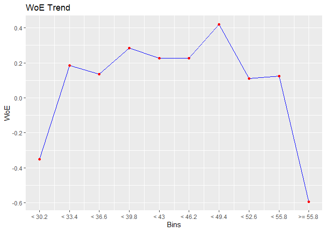

```r
# plot
plot(bins)
```